# ReadingSkills Dataset: Table1 plus Analysis

Author

Travis Keep (Advisor: Dr. Seals)

Published

October 10, 2024

## ReadingSkills dataset

Here are the description of the columns

| Name | Type | Description |
| --- | --- | --- |
| accuracy | numeric | Reading score with max of 0.99 |
| dyslexia | character | Yes for dyslexic, No for not dyslexic |
| iq | numeric | Non verbal intelligence quotient transform to z score |
| accuracy1 | numeric | same as accuracy but score goes up to 1.0 |

```r
library(betareg)
library(dplyr)
library(magrittr)
data("ReadingSkills")

dyslexia <- ReadingSkills %>% filter(dyslexia == "yes")
normal <- ReadingSkills %>% filter(dyslexia == "no")
n <- (ReadingSkills %>% dim)[1]
ndyslexia <- (dyslexia %>% dim)[1]
nnormal <- (normal %>% dim)[1]
iq_stats <- ReadingSkills %>% summarize(min(iq), median(iq), max(iq))
iq_dyslexia_stats <- dyslexia %>% summarize(min(iq), median(iq), max(iq))
iq_normal_stats <- normal %>% summarize(min(iq), median(iq), max(iq))
score_stats <- ReadingSkills %>% summarize(min(accuracy1), median(accuracy1), max(accuracy1))
score_dyslexia_stats <- dyslexia %>% summarize(min(accuracy1), median(accuracy1), max(accuracy1))
score_normal_stats <- normal %>% summarize(min(accuracy1), median(accuracy1), max(accuracy1))
```

Table1: Student ReadingSkills data stratified by dyslexia

| student characteristic | Total(n=44) | Dyslexia(n=19) | Normal(n=25) |
| --- | --- | --- | --- |
| IQ (Z score) | min -1.745 median -0.1225 max 1.856 | min -1.745 median -0.795 max 1.223 | min -0.914 median 0.59 max 1.856 |
| Reading Score | min 0.45932 median 0.70593 max 1 | min 0.45932 median 0.60916 max 0.70281 | min 0.64662 median 1 max 1 |

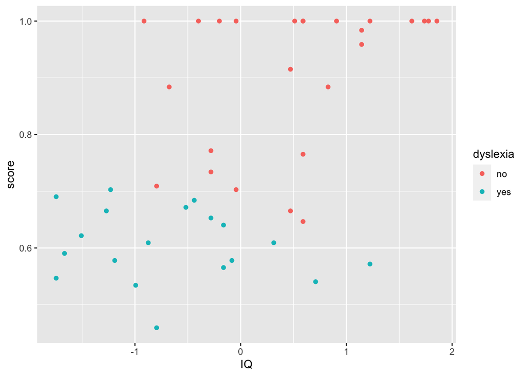

```r
library(ggplot2)
coords <- aes(x=iq, y=accuracy1)
ggplot(ReadingSkills, coords) + geom_point(aes(color=dyslexia)) + labs(x="IQ", y="score")
```

## Analysis

In this section, we do beta regression analysis on the ReadingSkills data set. To visualise the regression, we split the results into dyslexic children and normal children. We model phi as constant as that gives a pseduo $R^2$ of 0.6067 instead of 0.5089.

```r
ReadingSkillsModel <- ReadingSkills %>% mutate(dcode=ifelse(dyslexia == "no", -0.5, 0.5))

model <- betareg(accuracy ~ dcode*iq, data=ReadingSkillsModel, type="BC")
summary(model)
```

```
Call:
betareg(formula = accuracy ~ dcode * iq, data = ReadingSkillsModel, type = "BC")

Quantile residuals:
    Min      1Q  Median      3Q     Max
-2.2624 -0.4148  0.0724  0.4798  1.6967

Coefficients (mean model with logit link):
            Estimate Std. Error z value Pr(>|z|)
(Intercept)   1.3177     0.1438   9.160  < 2e-16 ***
dcode        -1.9203     0.2822  -6.804 1.02e-11 ***
iq            0.1578     0.1408   1.120    0.263
dcode:iq     -0.4299     0.2818  -1.525    0.127

Phi coefficients (precision model with identity link):
      Estimate Std. Error z value Pr(>|z|)
(phi)    9.520      2.096   4.543 5.55e-06 ***
---
Signif. codes:  0 '***' 0.001 '**' 0.01 '*' 0.05 '.' 0.1 ' ' 1

Type of estimator: BC (bias-corrected)
Log-likelihood: 51.09 on 5 Df
Pseudo R-squared: 0.6067
Number of iterations: 20 (BFGS) + 2 (Fisher scoring)
```

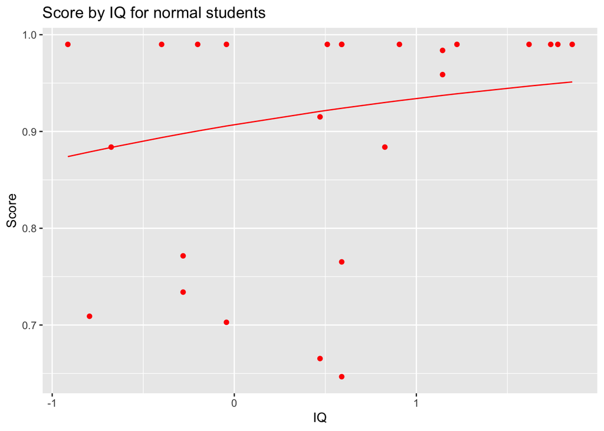

```r
dyslexiaModel <- ReadingSkillsModel %>% filter(dyslexia == "yes")
normalModel <- ReadingSkillsModel %>% filter(dyslexia == "no")

ggplot() + geom_point(aes(x=normalModel$iq, y=normalModel$accuracy), color="red") + geom_line(aes(x=normalModel$iq, y=predict(model, newdata=normalModel)), color="red") + xlab("IQ") + ylab("Score") + ggtitle("Score by IQ for normal students")
```

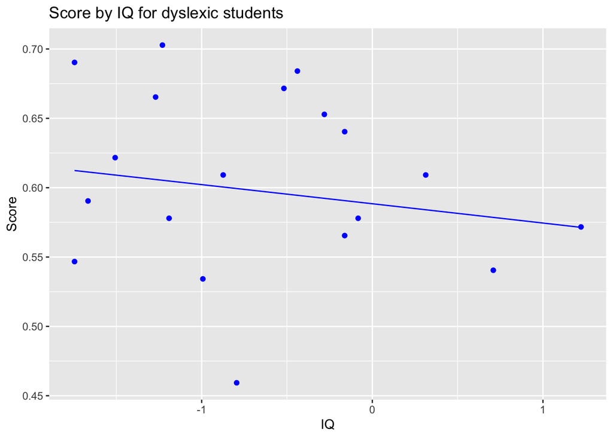

```r
ggplot() + geom_point(aes(x=dyslexiaModel$iq, y=dyslexiaModel$accuracy), color="blue") + geom_line(aes(x=dyslexiaModel$iq, y=predict(model, newdata=dyslexiaModel)), color="blue") + xlab("IQ") + ylab("Score") + ggtitle("Score by IQ for dyslexic students")
```

## Conclusion

The table1 and plot indicate that whether or not a child has dyslexia is significant in predicting the reading skills score. Also, they indicate that in this study, the non dyslexic children seemed to have higher IQs than the dyslexic children.

```r
# loading packages
library(tidyverse)
library(knitr)
library(ggthemes)
library(ggrepel)
library(dslabs)
```